# MP2

Tingwei Hu, Eugene Yang, Anya Zhong, Andriana Patmanidis

2023-02-15

# Introduction

The classic inverted pendulum (IP) model is a powerful tool for analyzing the Newtonian physics and mechanisms underlying bipedal locomotion. This mathematical model predicts that the square of the maximum velocity is less than or equal to the product of gravity and the pendulum length: $v^2 ≤ gL$. For predicting bipedal locomotion, the IP model suggests that the maximum walking speed is defined as being less than or equal to $\sqrt{gL}$, where L represents leg length. However, this result may not accurately describe realized human gaits as it fails to consider other elements that contribute to walking such as mass and movement of surrounding structures. To evaluate the IP model’s ability in accurately predicting human walking, we will investigate the difference in maximum walking velocities under pendulum walking and normal walking, and the changes in pelvic tilt angle at various normal walking speeds.

# Methods

## Data Collection

Leg length and body mass were collected for each group member. Pendulum walking speed, slow normal walking speed, and fast normal walking speed were recorded for each group member over 5 meters. In the latter two conditions, a meter stick marked at the center and one of the ends was attached horizontally to the subject’s waist area. Videos were taken from in front of the subject’s walking path. The video footage was converted from MOV into AVI files and analyzed using ImageJ with the MTrackJ plugin. The dot at the center of the subjects’ hips was designated as point 1, and the dot lateral of the left hip was designated as point 2. Points 1 and 2 were labeled on each frame where the subject was actively engaged in walking for each of their two files. The video files were rotated 90º counter clockwise, so the y-axis of the image represents the horizontal distance relative to the orientation subject, and the x-axis of the image represents the vertical distance relative to the orientation subject. The data containing the positioning of these labeled points were exported as text files and loaded into R studio. The pelvic tilt angle was calculated as the arctan of the vertical distance (difference along the x-axis) over the horizontal distance (difference along the y-axis) for each AVI file. Class-wide data were obtained from table linked from the project description page.

```
## # A tibble: 6 × 7
## # Groups:   speed, subject [1]
##     PID subject speed x_hipR x_hipC y_hipR y_hipC
##   <dbl> <chr>   <chr>  <dbl>  <dbl>  <dbl>  <dbl>
## 1     1 ap      fast     786    782     14    116
## 2     2 ap      fast     786    784     14    116
## 3     3 ap      fast     786    784     18    118
## 4     4 ap      fast     786    786     18    118
## 5     5 ap      fast     786    786     18    118
## 6     6 ap      fast     786    786     16    118
```

*Table 1. This table shows the pelvic tilt angle data collected from our team grouped by subject and speed.*

```
## # A tibble: 101 × 9
##      `0` sex    leg_length_m Mass_Kg vmax_ms^-…¹ recor…² Froud…³ norm_…⁴ fast_…⁵
##    <dbl> <chr>         <dbl>   <dbl>       <dbl>   <dbl>   <dbl>   <dbl>   <dbl>
##  1     1 Female        0.83     60          2.85   1.29    0.453    5.68    5.15
##  2     2 Female        0.84     58.2        2.87   1.61    0.56     7.77    8.99
##  3     4 Female        0.864    56.7        2.91   1.35    0.464    3.19    4.35
##  4     5 Female        0.88     47.6        2.94   1.12    0.382    5.64    7.48
##  5     6 Female        0.88     55.3        2.94   1.96    0.667    8.17    9.45
##  6     7 Male          0.885    77.1        2.95   1.20    0.406    2.17    6.72
##  7     8 Female        0.885    56.7        2.95   1.21    0.410    8.77   10.6
##  8     9 Female        0.9      52.2        2.97   0.932   0.314    5.65    7.08
##  9    10 Male          0.91     74.8        2.98   1.58    0.53     5.08    5.01
## 10    11 Female        0.91     59.0        2.99   1.67    0.558    6.85    7.23
## # … with 91 more rows, and abbreviated variable names ¹`vmax_ms^-1`,
## #   ²`recorded_walking_ms^-1`, ³Froude_number, ⁴norm_mean_max_pt_angle,
## #   ⁵fast_mean_max_pt_angle
```

*Table 2. This table organizes all of the pelvic tilt data collected from current and past individuals.*

# Results

## Report Question 1

A t-test with an alpha of 0.05 was performed to compare theoretical walking and realized walking speeds reported in the class data.

```
##
##  Paired t-test
##
## data:  class.gait$`vmax_ms^-1` and class.gait$`recorded_walking_ms^-1`
## t = 41.09, df = 100, p-value < 2.2e-16
## alternative hypothesis: true mean difference is not equal to 0
## 95 percent confidence interval:
##  1.634748 1.800619
## sample estimates:
## mean difference
##        1.717684
```

```
## # A tibble: 101 × 3
##       ID ratio Froude_number
##    <dbl> <dbl>         <dbl>
##  1     1 0.453         0.453
##  2     2 0.561         0.56
##  3     4 0.464         0.464
##  4     5 0.382         0.382
##  5     6 0.667         0.667
##  6     7 0.406         0.406
##  7     8 0.410         0.410
##  8     9 0.314         0.314
##  9    10 0.530         0.53
## 10    11 0.558         0.558
## # … with 91 more rows
```

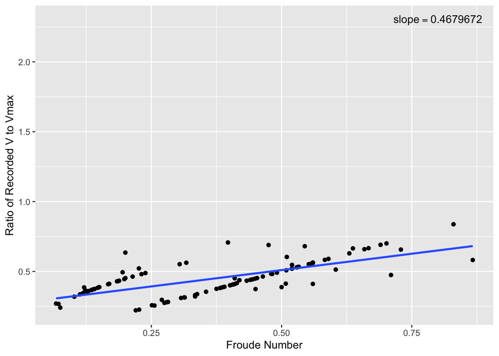

Figure 1. This figure depicts the relationship between the ratio of the recorded velocity for pendulum walking to the predicted maximum velocity and the Froude number

## Report Question 2

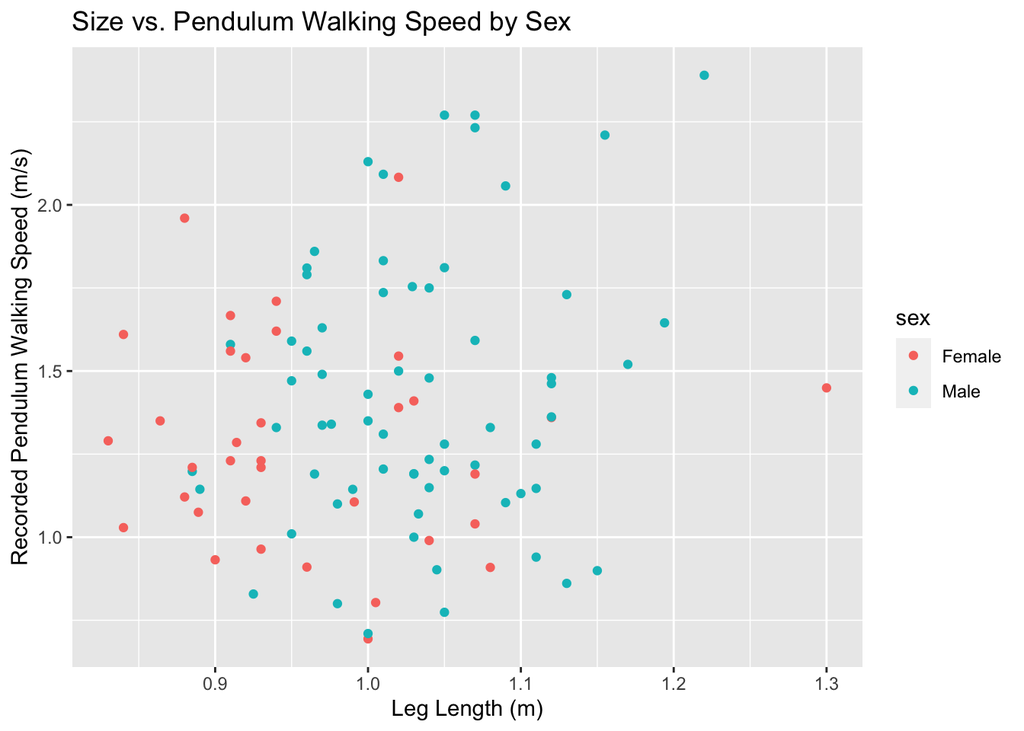

Figure 2. Leg length was plotted against recorded pendulum walking speed for each individual with complete information in the class data set, and color coded based on reported sex

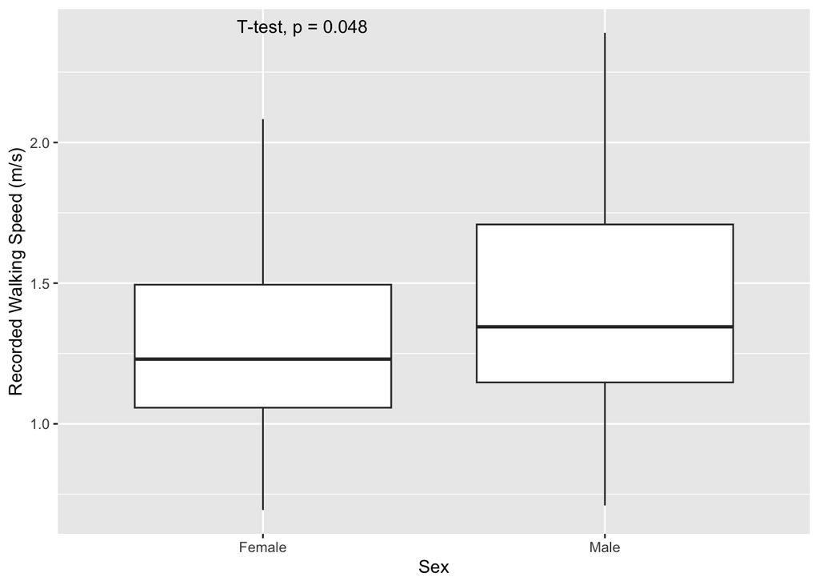

Figure 3. This boxplot represents the recorded pendulum walking speed separated by sex, and a t-test with an alpha of 0.05 reported a p-value of 0.048

```
##
##  Welch Two Sample t-test
##
## data:  leg_length_m by sex
## t = -3.9714, df = 55.55, p-value = 0.0002075
## alternative hypothesis: true difference in means between group Female and group Male is not equal to 0
## 95 percent confidence interval:
##  -0.10960211 -0.03609659
## sample estimates:
## mean in group Female   mean in group Male
##            0.9605143            1.0333636
```

```
## Anova Table (Type III tests)
##
## Response: recorded_walking_ms^-1
##               Sum Sq Df F value  Pr(>F)
## (Intercept)   0.5540  1  3.8765 0.05179 .
## sex           0.2664  1  1.8642 0.17527
## leg_length_m  0.1045  1  0.7315 0.39448
## Residuals    14.0056 98
## ---
## Signif. codes:  0 '***' 0.001 '**' 0.01 '*' 0.05 '.' 0.1 ' ' 1
```

Our data shows only a slightly significant correlation between walking speed and sex (p=0.048). Females had an average walking speed of 1.29m/s while males had an average speed of 1.43m/s.

## Report Question 3

```
## # A tibble: 101 × 2
##       ID difference
##    <dbl>      <dbl>
##  1     1    -0.530
##  2     2     1.22
##  3     4     1.16
##  4     5     1.84
##  5     6     1.28
##  6     7     4.55
##  7     8     1.88
##  8     9     1.43
##  9    10    -0.0700
## 10    11     0.384
## # … with 91 more rows
```

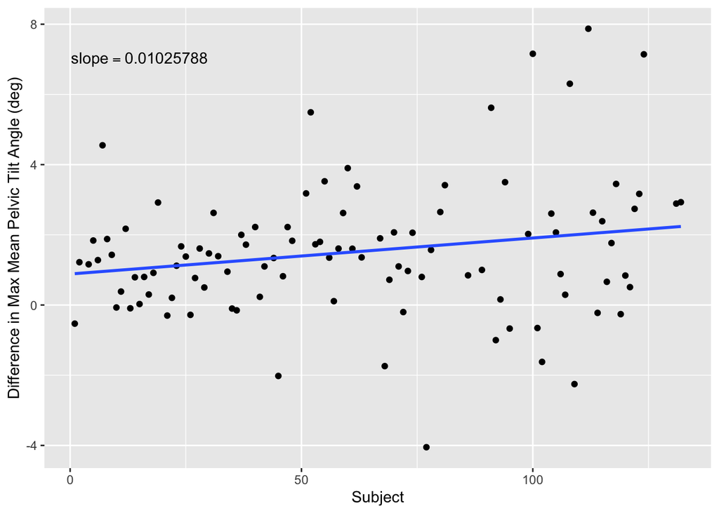

Figure 4. This figure depicts the difference in max mean pelvic tilt angle between a fast walking speed and a slow walking speed

## Report Question 4

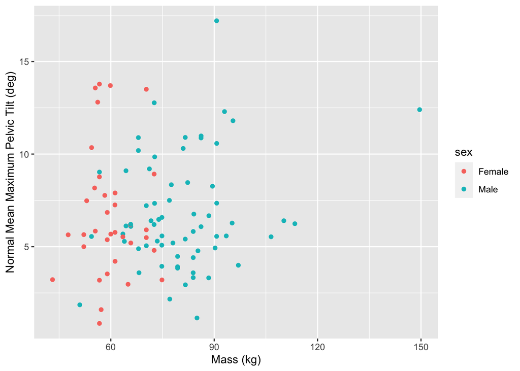

Figure 5. This figure depicts the relationship between mean max pelvic tilt angle (deg) and mass (kg). The data is further categorized by the individual’s sex.

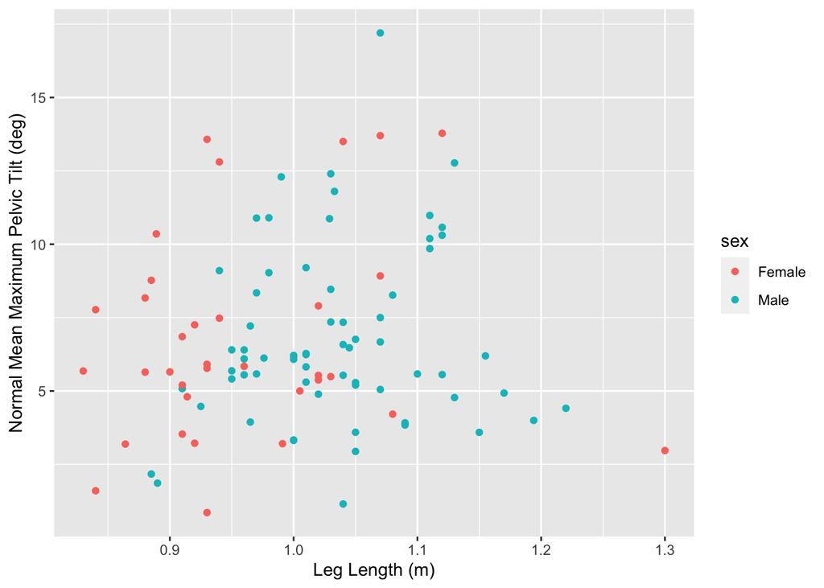

Figure 6. This figure depicts the relationship between mean max pelvic tilt angle (deg) and leg length (m). The data is further categorized by the individual’s sex.

```
##             Df Sum Sq Mean Sq F value Pr(>F)
## Mass_Kg      1   14.6  14.560    1.47  0.228
## Residuals   99  980.5   9.904
```

```
##              Df Sum Sq Mean Sq F value Pr(>F)
## leg_length_m  1   14.1  14.105   1.423  0.236
## Residuals    99  980.9   9.909
```

# Discussion

## Report Question 1

The class-wide theoretical pendulum walking speed was significantly larger than actual recorded pendulum walking speed as shown by the paired t-test. The p-value was found to be less than $2.2^-16 $, suggesting that there is a true difference in walking speed. In addition, based on the trend in figure 1 it appears that the calculated Froude number reflects the disparity in walking speed since the Froude number increases towards 1 as the ratio between theoretical and experimental speed also approaches 1.

## Report Question 2

Our data shows only a slightly significant correlation between walking speed and sex (p=0.048). Females had an average walking speed of 1.29m/s while males had an average speed of 1.43m/s. This data is based on the comparison of males and females during gait, so it is unclear as to exactly which factors contribute to this significant difference. According to Lewis et al. (2017), it is anatomically proven that pelvic structural differences exist between biologically male and female persons. Females tend to have wider, broader hips while males have a narrower pelvis and a more anteriorly curved sacrum. Differences in bone shape alter the structure of the acetabulum or hip joint, which may cause changes in the motion of walking. The article stated that “it remains unclear if these sex-specific differences during gait are related to specific pelvic structure or to differences in body size and height”. After performing an ANCOVA test that examined the covariance among categorical and continuous variables, it can be concluded that there is no significant difference between sex (p=0.175) or leg length (p=0.394) and gait speed.Therefore, it was not possible to draw concrete conclusions as to how human size and sex impact an individual’s gait speed.

## Report Question 3

In figure 4 above, we wanted to see how the max mean pelvic tilt angle would change depending on walking speed. We subtracted the normal max mean pelvic tilt angle from the fast max mean pelvic tilt angle to find the difference between the two. We expected there to be a greater max mean pelvic tilt angle while walking faster compared to walking slower. The data confirmed our expectations as the majority of individuals have a positive difference in max mean pelvic tilt angle between their fast and normal walking speeds. The biomechanical basis was explained in Whitcome, Miller, and Burns (2017), which stated that an increase in walking speed is associated with an increase in amplitude of pelvic rotation due to the fact that pelvic step accounts for a greater percentage of total step length.

## Report Question 4

The data we collected indicates that neither leg length nor body mass has a strong statistical impact on the max mean pelvic tilt angle. Our figures showed that there is not a large difference between the impact of mass and leg length on pelvic tilt angles. However, the graph of the mass data was much more clustered and accurate. Two one-way anova tests found neither mass (p=0.228) nor leg length (p=0.236) significantly affected mean pelvic tilt angle. However, mass did seem to be slightly more correlated to pelvic tilt angle compared to the impact that leg lengths do.

# Conclusion

In this experiment, bipedal locomotion was modeled by an inverted pendulum. Students performed walking trials that varied in speed (fast and slow) and form (normal and locked knee). It was evident that the class-wide theoretical velocity was significantly larger than the recorded pendulum walking speed. As the calculated Froude number increased, the ratio of the recorded velocity for pendulum walking to the predicted maximum velocity also increased, which signifies that there were points in time when both feet were lifted off the ground. Thus, this is not a reliable model for pendulum walking. In addition, it is not possible to draw concrete conclusions as to how human size and sex impact an individual’s gait speed. Our data showed slightly significant differences between walking speed and sex. After further statistical testing emphasizing covariance, it was concluded that correlations between sex or leg length and gait speed were not significant. Measurements of pelvic tilt were collected in conjunction with speed during gait. The majority of individuals had a greater maximum mean pelvic tilt angle while walking faster compared to walking slower. However, further data collection showed neither leg length nor body mass have a strong statistical impact on the maximum mean pelvic tilt angle.

# Author Contributions

Authors contributed equally on all parts of the project.

# References

Lewis, Cara L, Natalie M Laudicina, Anne Khuu, and Kari L Loverro. 2017. “The Human Pelvis: Variation in Structure and Function During Gait.” *The Anatomical Record* 300 (4): 633–42.

Whitcome, Katherine K, E Elizabeth Miller, and Jessica L Burns. 2017. “Pelvic Rotation Effect on Human Stride Length: Releasing the Constraint of Obstetric Selection.” *The Anatomical Record* 300 (4): 752–63.